# Prediction Assignment Writeup: predict barbell lifts correctness

Rene Larsson

Thursday, September 17, 2015

The goal of the project is to predict if the 6 participants did barbell lifts correctly or incorrectly. This report will describe how to build a predictive model.

The training and testing sets are available from the following sources:

https://d396qusza40orc.cloudfront.net/predmachlearn/pml-training.csv

https://d396qusza40orc.cloudfront.net/predmachlearn/pml-testing.csv

Load the libraries:

```r
library(randomForest)
library(caret)
```

Load the data sets:

```r
pmlTraining = read.csv("./pml-training.csv")
pmlTesting = read.csv("./pml-testing.csv")
```

The testing set will only be used to predict the classes on the model fit for the submission.

Examine the data:

```r
dim(pmlTraining)
```

```
## [1] 19622   160
```

```r
head(str(pmlTraining))
```

```
## 'data.frame':    19622 obs. of  160 variables:
##  $ X                       : int  1 2 3 4 5 6 7 8 9 10 ...
##  $ user_name               : Factor w/ 6 levels "adelmo","carlitos",..: 2 2 2 2 2 2 2 2 2 2 ...
##  $ raw_timestamp_part_1    : int  1323084231 1323084231 1323084231 1323084232 1323084232 1323084232 1323084232 1323084232 1323084232 1323084232 ...
##  $ raw_timestamp_part_2    : int  788290 808298 820366 120339 196328 304277 368296 440390 484323 484434 ...
##  $ cvtd_timestamp          : Factor w/ 20 levels "02/12/2011 13:32",..: 9 9 9 9 9 9 9 9 9 9 ...
##  $ new_window              : Factor w/ 2 levels "no","yes": 1 1 1 1 1 1 1 1 1 1 ...
##  $ num_window              : int  11 11 11 12 12 12 12 12 12 12 ...
##  $ roll_belt               : num  1.41 1.41 1.42 1.48 1.48 1.45 1.42 1.42 1.43 1.45 ...
##  $ pitch_belt              : num  8.07 8.07 8.07 8.05 8.07 8.06 8.09 8.13 8.16 8.17 ...
##  $ yaw_belt                : num  -94.4 -94.4 -94.4 -94.4 -94.4 -94.4 -94.4 -94.4 -94.4 -94.4 ...
##  $ total_accel_belt        : int  3 3 3 3 3 3 3 3 3 3 ...
##  $ kurtosis_roll_belt      : Factor w/ 397 levels "","-0.016850",..: 1 1 1 1 1 1 1 1 1 1 ...
##  $ kurtosis_picth_belt     : Factor w/ 317 levels "","-0.021887",..: 1 1 1 1 1 1 1 1 1 1 ...
##  $ kurtosis_yaw_belt       : Factor w/ 2 levels "","#DIV/0!": 1 1 1 1 1 1 1 1 1 1 ...
```

[output cut: 86 more lines]

Our interest lie on the movement predictors and inspection shows that the set contains personal data and other predictors that can be removed - ‘X’, ‘username’, ‘raw timestamp part1’, ‘raw timestamp part2’, ‘cvtd timestamp’, ‘new window’ and ‘num window’. The data must be pre-processed.

Remove NA filled and irrelevant predictors by concatenating relevant predictors:

```r
predictors = c("roll_belt", "pitch_belt", "yaw_belt", "total_accel_belt","gyros_belt_x", "gyros_belt_y", "gyros_belt_z", "accel_belt_x", "accel_belt_y","accel_belt_z", "magnet_belt_x", "magnet_belt_y", "magnet_belt_z", "roll_arm","pitch_arm", "yaw_arm", "total_accel_arm", "gyros_arm_x", "gyros_arm_y","gyros_arm_z", "accel_arm_x", "accel_arm_y", "accel_arm_z", "magnet_arm_x","magnet_arm_y", "magnet_arm_z", "roll_dumbbell", "pitch_dumbbell", "yaw_dumbbell","total_accel_dumbbell", "gyros_dumbbell_x", "gyros_dumbbell_y", "gyros_dumbbell_z","accel_dumbbell_x", "accel_dumbbell_y", "accel_dumbbell_z", "magnet_dumbbell_x","magnet_dumbbell_y", "magnet_dumbbell_z", "roll_forearm", "pitch_forearm","yaw_forearm", "total_accel_forearm", "gyros_forearm_x", "gyros_forearm_y","gyros_forearm_z", "accel_forearm_x", "accel_forearm_y", "accel_forearm_z","magnet_forearm_x", "magnet_forearm_y", "magnet_forearm_z")
```

1. Add new predictors to test set
2. Add outcome to new predictors
3. Add outcome/new predictors to training set

```r
proTesting = pmlTesting[, predictors]
predictors = c(predictors, "classe")
proTraining = pmlTraining[, predictors]
```

Examine the data clean up:

```r
dim(proTraining)
```

```
## [1] 19622    53
```

```r
summary(proTraining)
```

```
##    roll_belt        pitch_belt          yaw_belt       total_accel_belt
##  Min.   :-28.90   Min.   :-55.8000   Min.   :-180.00   Min.   : 0.00
##  1st Qu.:  1.10   1st Qu.:  1.7600   1st Qu.: -88.30   1st Qu.: 3.00
##  Median :113.00   Median :  5.2800   Median : -13.00   Median :17.00
##  Mean   : 64.41   Mean   :  0.3053   Mean   : -11.21   Mean   :11.31
##  3rd Qu.:123.00   3rd Qu.: 14.9000   3rd Qu.:  12.90   3rd Qu.:18.00
##  Max.   :162.00   Max.   : 60.3000   Max.   : 179.00   Max.   :29.00
##   gyros_belt_x        gyros_belt_y       gyros_belt_z
##  Min.   :-1.040000   Min.   :-0.64000   Min.   :-1.4600
##  1st Qu.:-0.030000   1st Qu.: 0.00000   1st Qu.:-0.2000
##  Median : 0.030000   Median : 0.02000   Median :-0.1000
##  Mean   :-0.005592   Mean   : 0.03959   Mean   :-0.1305
##  3rd Qu.: 0.110000   3rd Qu.: 0.11000   3rd Qu.:-0.0200
##  Max.   : 2.220000   Max.   : 0.64000   Max.   : 1.6200
##   accel_belt_x       accel_belt_y     accel_belt_z     magnet_belt_x
##  Min.   :-120.000   Min.   :-69.00   Min.   :-275.00   Min.   :-52.0
##  1st Qu.: -21.000   1st Qu.:  3.00   1st Qu.:-162.00   1st Qu.:  9.0
##  Median : -15.000   Median : 35.00   Median :-152.00   Median : 35.0
##  Mean   :  -5.595   Mean   : 30.15   Mean   : -72.59   Mean   : 55.6
##  3rd Qu.:  -5.000   3rd Qu.: 61.00   3rd Qu.:  27.00   3rd Qu.: 59.0
##  Max.   :  85.000   Max.   :164.00   Max.   : 105.00   Max.   :485.0
##  magnet_belt_y   magnet_belt_z       roll_arm         pitch_arm
##  Min.   :354.0   Min.   :-623.0   Min.   :-180.00   Min.   :-88.800
##  1st Qu.:581.0   1st Qu.:-375.0   1st Qu.: -31.77   1st Qu.:-25.900
##  Median :601.0   Median :-320.0   Median :   0.00   Median :  0.000
##  Mean   :593.7   Mean   :-345.5   Mean   :  17.83   Mean   : -4.612
##  3rd Qu.:610.0   3rd Qu.:-306.0   3rd Qu.:  77.30   3rd Qu.: 11.200
##  Max.   :673.0   Max.   : 293.0   Max.   : 180.00   Max.   : 88.500
##     yaw_arm          total_accel_arm  gyros_arm_x        gyros_arm_y
##  Min.   :-180.0000   Min.   : 1.00   Min.   :-6.37000   Min.   :-3.4400
##  1st Qu.: -43.1000   1st Qu.:17.00   1st Qu.:-1.33000   1st Qu.:-0.8000
##  Median :   0.0000   Median :27.00   Median : 0.08000   Median :-0.2400
##  Mean   :  -0.6188   Mean   :25.51   Mean   : 0.04277   Mean   :-0.2571
##  3rd Qu.:  45.8750   3rd Qu.:33.00   3rd Qu.: 1.57000   3rd Qu.: 0.1400
##  Max.   : 180.0000   Max.   :66.00   Max.   : 4.87000   Max.   : 2.8400
##   gyros_arm_z       accel_arm_x       accel_arm_y      accel_arm_z
##  Min.   :-2.3300   Min.   :-404.00   Min.   :-318.0   Min.   :-636.00
##  1st Qu.:-0.0700   1st Qu.:-242.00   1st Qu.: -54.0   1st Qu.:-143.00
##  Median : 0.2300   Median : -44.00   Median :  14.0   Median : -47.00
##  Mean   : 0.2695   Mean   : -60.24   Mean   :  32.6   Mean   : -71.25
```

[output cut: 50 more lines]

```
##  Max.   :311.00000   Max.   :231.0000   Max.   : 477.00   Max.   : 923.0
##  accel_forearm_z   magnet_forearm_x  magnet_forearm_y magnet_forearm_z
##  Min.   :-446.00   Min.   :-1280.0   Min.   :-896.0   Min.   :-973.0
##  1st Qu.:-182.00   1st Qu.: -616.0   1st Qu.:   2.0   1st Qu.: 191.0
##  Median : -39.00   Median : -378.0   Median : 591.0   Median : 511.0
##  Mean   : -55.29   Mean   : -312.6   Mean   : 380.1   Mean   : 393.6
##  3rd Qu.:  26.00   3rd Qu.:  -73.0   3rd Qu.: 737.0   3rd Qu.: 653.0
##  Max.   : 291.00   Max.   :  672.0   Max.   :1480.0   Max.   :1090.0
##  classe
##  A:5580
##  B:3797
##  C:3422
##  D:3216
##  E:3607
##
```

Examine correlations and potential bias: 1. calculate value of correlation - leave out the outcome 2. create heatmap of correlation value

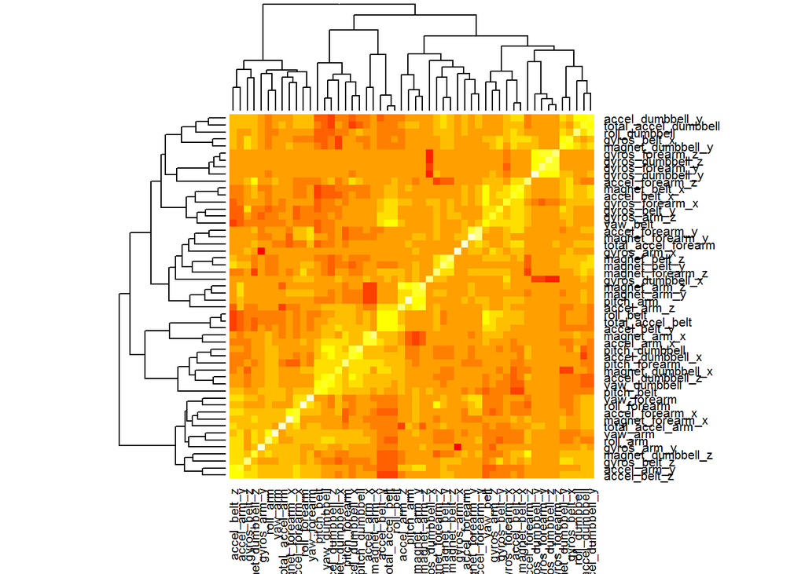

```r
corrTrain = cor(proTraining[, names(proTraining) != "classe"])
heatmap(corrTrain)
```

The heat map indicates that few predictors correlate, but those that do seem highly correlated.This can be further explored by thresholding:

1. set diagonal of matrices to zero (1:1 correlations)
2. examine predictors that have a correlation greater than .8 treshhold
3. identify predictors

```r
diag(corrTrain) = 0
corrTrain[corrTrain < -0.8 | corrTrain > 0.8]
```

```
##  [1]  0.8152297  0.9809241  0.9248983 -0.9920085 -0.9657334 -0.8841727
##  [7]  0.8152297  0.9809241  0.9278069 -0.9749317 -0.9657334  0.8920913
## [13]  0.9248983  0.9278069 -0.9333854 -0.9920085 -0.9749317 -0.9333854
## [19] -0.8841727  0.8920913 -0.9181821 -0.9181821  0.8142732  0.8142732
## [25]  0.8144455  0.8144455  0.8082885  0.8491322 -0.9789507 -0.9144764
## [31] -0.9789507  0.9330422  0.8082885  0.8491322  0.8455626 -0.9144764
## [37]  0.9330422  0.8455626
```

```r
which(corrTrain < -0.8 | corrTrain > 0.8, arr.ind=T)
```

```
##                  row col
## yaw_belt           3   1
## total_accel_belt   4   1
## accel_belt_y       9   1
## accel_belt_z      10   1
## accel_belt_x       8   2
## magnet_belt_x     11   2
## roll_belt          1   3
## roll_belt          1   4
## accel_belt_y       9   4
## accel_belt_z      10   4
## pitch_belt         2   8
## magnet_belt_x     11   8
## roll_belt          1   9
## total_accel_belt   4   9
## accel_belt_z      10   9
## roll_belt          1  10
## total_accel_belt   4  10
## accel_belt_y       9  10
## pitch_belt         2  11
## accel_belt_x       8  11
## gyros_arm_y       19  18
## gyros_arm_x       18  19
## magnet_arm_x      24  21
## accel_arm_x       21  24
## magnet_arm_z      26  25
## magnet_arm_y      25  26
## accel_dumbbell_x  34  28
## accel_dumbbell_z  36  29
## gyros_dumbbell_z  33  31
## gyros_forearm_z   46  31
## gyros_dumbbell_x  31  33
## gyros_forearm_z   46  33
## pitch_dumbbell    28  34
## yaw_dumbbell      29  36
## gyros_forearm_z   46  45
## gyros_dumbbell_x  31  46
## gyros_dumbbell_z  33  46
## gyros_forearm_y   45  46
```

There are several pairs that are highly corelated, far beyond the threshold. It would be prudent to raise it in order to keep as many predictors as possible.

```r
corrTrain[which(corrTrain < -0.95 | corrTrain > 0.95, arr.ind=T)]
```

```
##  [1]  0.9809241 -0.9920085 -0.9657334  0.9809241 -0.9749317 -0.9657334
##  [7] -0.9920085 -0.9749317 -0.9789507 -0.9789507
```

```r
which(corrTrain < -0.95 |corrTrain > 0.95, arr.ind=T)
```

```
##                  row col
## total_accel_belt   4   1
## accel_belt_z      10   1
## accel_belt_x       8   2
## roll_belt          1   4
## accel_belt_z      10   4
## pitch_belt         2   8
## roll_belt          1  10
## total_accel_belt   4  10
## gyros_dumbbell_z  33  31
## gyros_dumbbell_x  31  33
```

```r
corrTrain[which(corrTrain < -0.98 | corrTrain > 0.98, arr.ind=T)]
```

```
## [1]  0.9809241 -0.9920085  0.9809241 -0.9920085
```

```r
which(corrTrain < -0.98 |corrTrain > 0.98, arr.ind=T)
```

```
##                  row col
## total_accel_belt   4   1
## accel_belt_z      10   1
## roll_belt          1   4
## roll_belt          1  10
```

Since roll_belt has a high correlation to two other predictors, it will be removed:

```r
predictors = c("pitch_belt", "yaw_belt", "total_accel_belt", "gyros_belt_x","gyros_belt_y", "gyros_belt_z", "accel_belt_x", "accel_belt_y", "accel_belt_z","magnet_belt_x", "magnet_belt_y", "magnet_belt_z", "roll_arm", "pitch_arm","yaw_arm", "total_accel_arm", "gyros_arm_x", "gyros_arm_y", "gyros_arm_z","accel_arm_x", "accel_arm_y", "accel_arm_z", "magnet_arm_x", "magnet_arm_y","magnet_arm_z", "roll_dumbbell", "pitch_dumbbell", "yaw_dumbbell", "total_accel_dumbbell","gyros_dumbbell_x", "gyros_dumbbell_y", "gyros_dumbbell_z", "accel_dumbbell_x","accel_dumbbell_y", "accel_dumbbell_z", "magnet_dumbbell_x", "magnet_dumbbell_y","magnet_dumbbell_z", "roll_forearm", "pitch_forearm", "yaw_forearm", "total_accel_forearm","gyros_forearm_x", "gyros_forearm_y", "gyros_forearm_z", "accel_forearm_x","accel_forearm_y", "accel_forearm_z", "magnet_forearm_x", "magnet_forearm_y","magnet_forearm_z")
```

1. Add predictors to test set
2. Add outcome to predictors
3. Add outcome/predictors to training set

```r
proTesting = pmlTesting[, predictors]
predictors = c(predictors, "classe")
proTraining = pmlTraining[, predictors]
```

The chosen model is random forest. This approach is accurate and widely used as a method for prediction. Yet, it is quite slow and can lead to overfitting. It is therefore important to cross validate in regards to the latter, and because of the former trees are set to 500:

1. Split the data
2. create training subset
3. create validation set

```r
inTrain = createDataPartition(y=proTraining$classe,p=0.5, list=FALSE)
trainSubset = proTraining[inTrain, ]
validation = proTraining[-inTrain, ]
```

Create the model:

1. fit model
2. inspect OOB and calculate accuracy

```r
set.seed(1405)
```

```r
modFit = randomForest(classe ~ ., data = trainSubset, ntree = 500)
modFit
```

```
##
## Call:
##  randomForest(formula = classe ~ ., data = trainSubset, ntree = 500)
##                Type of random forest: classification
##                      Number of trees: 500
## No. of variables tried at each split: 7
##
##         OOB estimate of  error rate: 0.83%
## Confusion matrix:
##      A    B    C    D    E  class.error
## A 2789    1    0    0    0 0.0003584229
## B   13 1878    8    0    0 0.0110584518
## C    0   21 1687    2    1 0.0140268849
## D    0    0   24 1582    2 0.0161691542
## E    0    0    3    6 1795 0.0049889135
```

The accuracy is app .99 (accuracy=diagonal/confusion matrix).

cross-validation:

1. predict the validation test the values on the modFit
2. Calculate accuracy of prediction

```r
set.seed(2015)
```

```r
predTest = predict(modFit, validation)
table(predTest, validation$classe)
```

```
##
## predTest    A    B    C    D    E
##        A 2781   17    0    0    0
##        B    6 1876   26    0    0
##        C    0    5 1680   23    5
##        D    2    0    5 1581    3
##        E    1    0    0    4 1795
```

```r
predAc = postResample(predTest, validation$classe)
predAc
```

```
##  Accuracy     Kappa
## 0.9901121 0.9874915
```

The accuracy is about the same, keeping in mind that sample test sets are more optimistic.

Predicted out of sample error rate:

```r
predError = confusionMatrix(predTest, validation$classe)
predError
```

```
## Confusion Matrix and Statistics
##
##           Reference
## Prediction    A    B    C    D    E
##          A 2781   17    0    0    0
##          B    6 1876   26    0    0
##          C    0    5 1680   23    5
##          D    2    0    5 1581    3
##          E    1    0    0    4 1795
##
## Overall Statistics
##
##                Accuracy : 0.9901
##                  95% CI : (0.988, 0.992)
##     No Information Rate : 0.2844
##     P-Value [Acc > NIR] : < 2.2e-16
##
##                   Kappa : 0.9875
##  Mcnemar's Test P-Value : NA
##
## Statistics by Class:
##
##                      Class: A Class: B Class: C Class: D Class: E
## Sensitivity            0.9968   0.9884   0.9819   0.9832   0.9956
## Specificity            0.9976   0.9960   0.9959   0.9988   0.9994
## Pos Pred Value         0.9939   0.9832   0.9807   0.9937   0.9972
## Neg Pred Value         0.9987   0.9972   0.9962   0.9967   0.9990
## Prevalence             0.2844   0.1935   0.1744   0.1639   0.1838
## Detection Rate         0.2835   0.1912   0.1713   0.1612   0.1830
## Detection Prevalence   0.2852   0.1945   0.1746   0.1622   0.1835
## Balanced Accuracy      0.9972   0.9922   0.9889   0.9910   0.9975
```

The estimated error rate is (1-accuracy).

Submission:

```r
predict(modFit, pmlTesting)
```

```
##  1  2  3  4  5  6  7  8  9 10 11 12 13 14 15 16 17 18 19 20
##  B  A  B  A  A  E  D  B  A  A  B  C  B  A  E  E  A  B  B  B
## Levels: A B C D E
```